## Data analyis

### Overview

The aim of this initial analysis is to take a look at the controls that we have. These include dilutions of caecal material from minimal microbiome mice (macpherson flora).

The dilution controls consist of two separate dilution series (1, 1:10, 1:100, 1:1000, 1:10000, 1:100000, 1:1000000) representing extractions from two different kits that were used to extract DNA - zymo and qiagen. The purpose of the dilution series was to identify potential kit/pcr contaminants - those ASVs that increase in relative abundance as DNA dilution increases will represent contaminating sequences. We expect a maximum of 12 ASVs for the dilution samples although inevitably there will be a number of additional ASVs that come from things like index-switching, sequencing errors and contamination.

### Members of the minimal flora

Below is a table of the taxa that are present in the 12 member community:

| Strain | Genus |
| --- | --- |
| Acutalibacter_muris_KB18 | Clostridium |
| Akkermansia_muciniphila_YL44 | Akkermansia |
| Bacteroides_caecimuris_strain_148 | Bacteroides |
| Bifidobacterium_animalis_subsp._animalis_YL2 | Bifidobacterium |
| Blautia_coccoides_YL58 | Blautia |
| Clostridium_clostridioforme_YL32 | Clostridium |
| Clostridium_inocuum_146 | Erysipelotrichaceae incertae sedis |
| Enterococcus_faecalis_KB1 | Enterococcus |
| Flavonifractor_plautii_YL31 | Flavonifractor |
| Lactobacillus_reuteri_149 | Lactobacillus |
| Muribaculum_intestinale_YL27 | Barnesiella |
| Turicimonas_muris_YL45 | Parasutterella |

### ASVs detected in each control sample.

I have started off just looking at some broad things in relation to amplicon sequence variants (ASVs). An ASV represents an exact sequence that is inferred to be present in the sample i.e. it is not a cluster of sequences like OTUs are. There are therefore more ASVs than there are species/strains etc because each strain may have multiple copies of the 16S rRNA gene. After an initial look at the level of ASVs I look at taxonomic distributions.

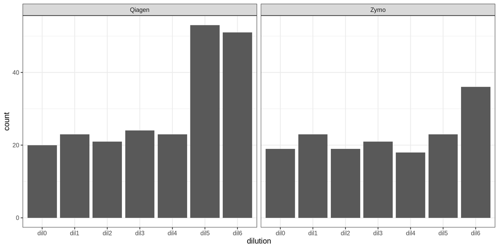

Number of ASVs found in control samples

The DNA concentrations (data not shown) do not seem to truly reflect the dilution series. However on inspection of the number of ASVs called it certainly looks like more ASVs are called the higher dilutions - particularly when using the Qiagen kit.

### Library size, DNA concentration and number of ASVs.

Here we assess the relationships between the library sizes, DNA concentrations and number of ASVs It is expected that the higher the DNA concentration, the more reads and thus the more ASVs will be called.

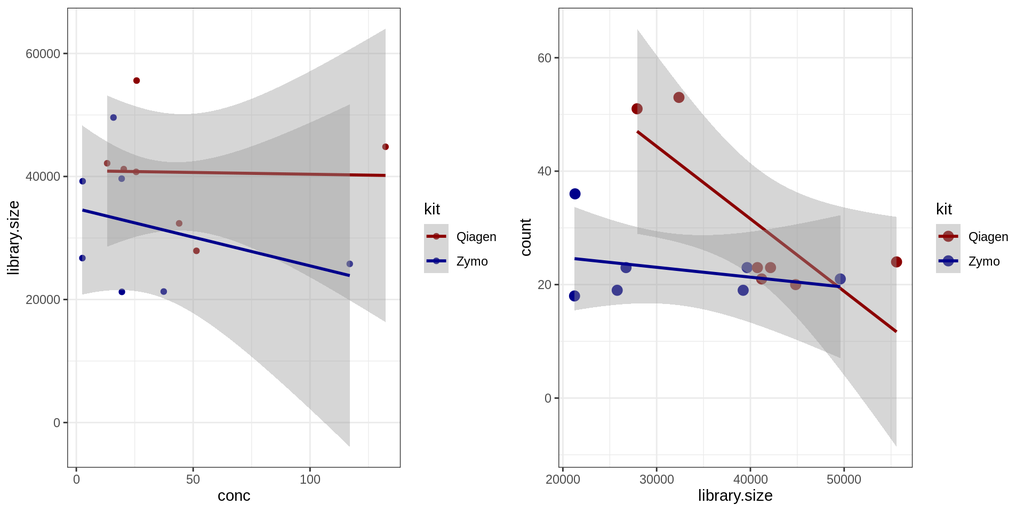

Library size as a function of DNA concentration

For the qiagen kit it certainly looks like the more dilute samples are calling more ASVs even though they do in general have lower library sizes. There is not much going on in the zymo kits.

### Total number of genera detected

While there is an ovecalling of ASVs in gereral, this is likely due to sequencing error and the actual taxonomic distribution would not be expected to deviate from what is expected i.e there are likely multiple ASVs called for each taxon that is in the MM12 community.

Here I look at taxonomic distributions - this is basically a collapsed version of ASVs i.e. if multiple sequence variants are assigned to a particular taxon then this will simply add to the count for that taxon. It is therefore a more high-level view of the microbiome than ASV analysis.

We are expecting to identify 10 genera. 11 strains in the minimal microbiome make up these 10 genera. The 12th strain which is Bifidobacteria we know will not be present at detectable levels in the caecal samples.

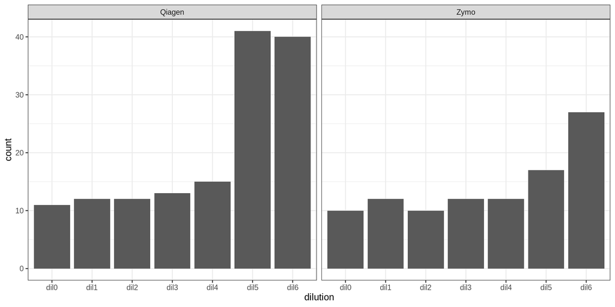

Number of genera detected in coltrol samples

From this plot it seems a bit clearer than the ASV analysis that at lower concentrations of sample DNA we are picking up more genera which represent contaminants of some description.

### Taxonomic distribution amongst controls

We are expecting to identify 10 genera. 11 strains in the minimal microbiome make up these 10 genera. The 12th strain which is Bifidobacteria we know will not be present at detectable levels in the caecal samples.

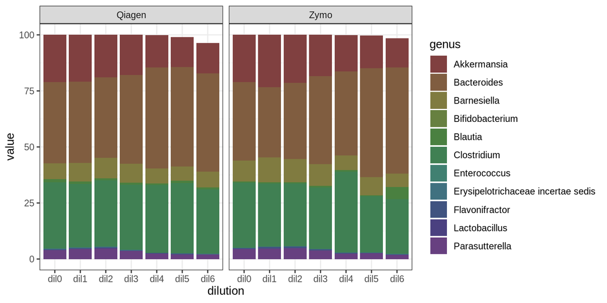

Abundance of genera in oligoMM12

Once again these data do show that at the highest dilution - especially for the Qiagen kit - that we see that contaminant genera ared creepin in.

### Number of reads that are correctly assigned to our genera

Below is a table of results that shows the number of reads that are correctly (well at least at the genus level) assigned to MM12 members. This is a rough guide on contaminating reads.

|  | kit | dilution | proportion.correct |
| --- | --- | --- | --- |
| AG121 | Zymo | dil0 | 100.00000 |
| AG122 | Zymo | dil1 | 99.98991 |
| AG123 | Zymo | dil2 | 100.00000 |
| AG124 | Zymo | dil3 | 100.00000 |
| AG125 | Zymo | dil4 | 99.94351 |
| AG126 | Zymo | dil5 | 99.68206 |
| AG127 | Zymo | dil6 | 98.49260 |
| AG128 | Qiagen | dil0 | 100.00000 |
| AG129 | Qiagen | dil1 | 99.99051 |
| AG130 | Qiagen | dil2 | 99.99515 |
| AG131 | Qiagen | dil3 | 99.98741 |
| AG132 | Qiagen | dil4 | 99.86993 |
| AG133 | Qiagen | dil5 | 98.92828 |
| AG134 | Qiagen | dil6 | 96.28860 |

### Filtering parameters

At the lowest concentration for the Qiagen kit ~4% reads are assigned to genera that shouldn’t be there. Nevertheless, if these are made up of multiple very low abundance genera then we could use these data to determine thresholds that should be used for thresholding our experimental samples. Below I look at various cut-offs and see how it affects the proportion of genera that are assigned correctly.

[output not shown]

[output cut: 561 more lines]

[output not shown]

| kit | dilution | proportion.correct | nfound | parameter |
| --- | --- | --- | --- | --- |
| Zymo | dil0 | 100.00000 | 13 | 0.001 |
| Zymo | dil1 | 99.98991 | 13 | 0.001 |
| Zymo | dil2 | 100.00000 | 13 | 0.001 |
| Zymo | dil3 | 100.00000 | 13 | 0.001 |
| Zymo | dil4 | 99.94351 | 13 | 0.001 |
| Zymo | dil5 | 99.68206 | 13 | 0.001 |
| Zymo | dil6 | 98.49260 | 13 | 0.001 |
| Qiagen | dil0 | 100.00000 | 13 | 0.001 |
| Qiagen | dil1 | 99.99051 | 13 | 0.001 |
| Qiagen | dil2 | 99.99515 | 13 | 0.001 |
| Qiagen | dil3 | 99.98741 | 13 | 0.001 |
| Qiagen | dil4 | 99.86993 | 13 | 0.001 |
| Qiagen | dil5 | 98.92828 | 13 | 0.001 |
| Qiagen | dil6 | 96.28860 | 13 | 0.001 |
| Zymo | dil0 | 100.00000 | 12 | 0.010 |
| Zymo | dil1 | 99.98991 | 12 | 0.010 |
| Zymo | dil2 | 100.00000 | 12 | 0.010 |
| Zymo | dil3 | 100.00000 | 12 | 0.010 |
| Zymo | dil4 | 99.94351 | 12 | 0.010 |
| Zymo | dil5 | 99.68206 | 12 | 0.010 |
| Zymo | dil6 | 98.49260 | 12 | 0.010 |
| Qiagen | dil0 | 100.00000 | 12 | 0.010 |
| Qiagen | dil1 | 99.99051 | 12 | 0.010 |
| Qiagen | dil2 | 99.99515 | 12 | 0.010 |
| Qiagen | dil3 | 99.98741 | 12 | 0.010 |
| Qiagen | dil4 | 99.86993 | 12 | 0.010 |
| Qiagen | dil5 | 98.98943 | 12 | 0.010 |
| Qiagen | dil6 | 96.28860 | 12 | 0.010 |
| Zymo | dil0 | 100.00000 | 9 | 0.100 |
| Zymo | dil1 | 99.98991 | 9 | 0.100 |
| Zymo | dil2 | 100.00000 | 9 | 0.100 |
| Zymo | dil3 | 100.00000 | 9 | 0.100 |
| Zymo | dil4 | 99.98116 | 9 | 0.100 |
| Zymo | dil5 | 99.80526 | 9 | 0.100 |
| Zymo | dil6 | 99.12879 | 9 | 0.100 |
| Qiagen | dil0 | 100.00000 | 9 | 0.100 |
| Qiagen | dil1 | 99.99051 | 9 | 0.100 |
| Qiagen | dil2 | 99.99514 | 9 | 0.100 |
| Qiagen | dil3 | 99.98741 | 9 | 0.100 |
| Qiagen | dil4 | 99.86991 | 9 | 0.100 |
| Qiagen | dil5 | 99.45031 | 9 | 0.100 |
| Qiagen | dil6 | 97.20093 | 9 | 0.100 |
| Zymo | dil0 | 100.00000 | 6 | 1.000 |
| Zymo | dil1 | 100.00000 | 6 | 1.000 |
| Zymo | dil2 | 100.00000 | 6 | 1.000 |
| Zymo | dil3 | 100.00000 | 6 | 1.000 |
| Zymo | dil4 | 100.00000 | 6 | 1.000 |
| Zymo | dil5 | 100.00000 | 6 | 1.000 |
| Zymo | dil6 | 100.00000 | 6 | 1.000 |
| Qiagen | dil0 | 100.00000 | 6 | 1.000 |
| Qiagen | dil1 | 100.00000 | 6 | 1.000 |
| Qiagen | dil2 | 100.00000 | 6 | 1.000 |
| Qiagen | dil3 | 100.00000 | 6 | 1.000 |
| Qiagen | dil4 | 100.00000 | 6 | 1.000 |
| Qiagen | dil5 | 100.00000 | 6 | 1.000 |
| Qiagen | dil6 | 100.00000 | 6 | 1.000 |

It only makes a big difference at a cutoff of 1%. This though may result in us not finding everything. Indeed we do not find all genera in the higher cut-offs. I think it is reasonable to use 0.1% as previously done as this gains something without throwing away too much.

### Potential contaminants

Although there isn’t a huge amount of concern over contaminants it will be useful to have a list of ASVs/taxa that are potentially contaminants. These are described below and are ASVs that are found in the MM12 that are not MM12.

| potential.contaminant.asvs | type |
| --- | --- |
| ASV10:p__Firmicutes;c__Clostridia;o__Clostridiales;f__Ruminococcaceae;g__Faecalibacterium;s__Faecalibacterium_prausnitzii(AJ413954) | MM12 |
| ASV22:p__Firmicutes;c__Clostridia;o__Clostridiales;f__Ruminococcaceae;g__Gemmiger;s__NA | MM12 |
| ASV62:p__Firmicutes;c__Clostridia;o__Clostridiales;f__Ruminococcaceae;g__Ruminococcus;s__NA | MM12 |
| ASV82:p__Firmicutes;c__NA;o__NA;f__NA;g__NA;s__NA | MM12 |
| ASV137:p__Firmicutes;c__Clostridia;o__Clostridiales;f__Ruminococcaceae;g__NA;s__NA | MM12 |
| ASV179:p__Proteobacteria;c__Alphaproteobacteria;o__Rhodospirillales;f__NA;g__NA;s__NA | MM12 |
| ASV340:p__Firmicutes;c__Clostridia;o__Clostridiales;f__Lachnospiraceae;g__NA;s__NA | MM12 |
| ASV358:p__Firmicutes;c__Clostridia;o__Clostridiales;f__Ruminococcaceae;g__Ruminococcus;s__Ruminococcus_callidus(L76596) | MM12 |
| ASV442:p__Proteobacteria;c__Gammaproteobacteria;o__Pseudomonadales;f__Moraxellaceae;g__Acinetobacter;s__Acinetobacter_lwoffii(X81665) | MM12 |
| ASV443:p__Proteobacteria;c__Betaproteobacteria;o__Burkholderiales;f__Comamonadaceae;g__Delftia;s__NA | MM12 |
| ASV444:p__Proteobacteria;c__Alphaproteobacteria;o__Caulobacterales;f__Caulobacteraceae;g__Caulobacter;s__NA | MM12 |
| ASV445:p__Actinobacteria;c__Actinobacteria;o__Actinomycetales;f__Propionibacteriaceae;g__Propionibacterium;s__NA | MM12 |
| ASV446:p__Proteobacteria;c__Gammaproteobacteria;o__Pseudomonadales;f__Moraxellaceae;g__Acinetobacter;s__NA | MM12 |
| ASV449:p__Proteobacteria;c__Gammaproteobacteria;o__Xanthomonadales;f__Xanthomonadaceae;g__Pseudoxanthomonas;s__NA | MM12 |
| ASV455:p__Actinobacteria;c__Actinobacteria;o__Actinomycetales;f__Dietziaceae;g__Dietzia;s__NA | MM12 |
| ASV614:p__Proteobacteria;c__Gammaproteobacteria;o__Pseudomonadales;f__Moraxellaceae;g__Acinetobacter;s__Acinetobacter_gandensis(KM206131) | MM12 |
| ASV616:p__Proteobacteria;c__Betaproteobacteria;o__Burkholderiales;f__Oxalobacteraceae;g__Herbaspirillum;s__Herbaspirillum_aquaticum(FJ267649) | MM12 |
| ASV622:p__Proteobacteria;c__Alphaproteobacteria;o__Rhizobiales;f__Bradyrhizobiaceae;g__NA;s__NA | MM12 |
| ASV624:p__Proteobacteria;c__Gammaproteobacteria;o__Enterobacteriales;f__Enterobacteriaceae;g__Serratia;s__Serratia_liquefaciens(AJ306725) | MM12 |
| ASV631:p__Proteobacteria;c__Alphaproteobacteria;o__Sphingomonadales;f__Sphingomonadaceae;g__NA;s__NA | MM12 |
| ASV642:p__Proteobacteria;c__Gammaproteobacteria;o__Pseudomonadales;f__Moraxellaceae;g__Acinetobacter;s__NA | MM12 |
| ASV645:p__Proteobacteria;c__Alphaproteobacteria;o__Rhodobacterales;f__Rhodobacteraceae;g__Paracoccus;s__Paracoccus_fistulariae(GQ260189) | MM12 |
| ASV651:p__Proteobacteria;c__Alphaproteobacteria;o__Rhizobiales;f__Rhizobiaceae;g__Neorhizobium;s__NA | MM12 |
| ASV768:p__Proteobacteria;c__Betaproteobacteria;o__Burkholderiales;f__Burkholderiaceae;g__Burkholderia;s__NA | MM12 |
| ASV778:p__Proteobacteria;c__Betaproteobacteria;o__Burkholderiales;f__Burkholderiaceae;g__Ralstonia;s__NA | MM12 |
| ASV782:p__Cyanobacteria/Chloroplast;c**Cyanobacteria;o**-;f__Family II;g__GpIIa;s__NA | MM12 |
| ASV812:p__Actinobacteria;c__Actinobacteria;o__Actinomycetales;f__Corynebacteriaceae;g__Corynebacterium;s__Corynebacterium_tuberculostearicum(AJ438050) | MM12 |
| ASV830:p__Bacteroidetes;c__Cytophagia;o__Cytophagales;f__Cytophagaceae;g__Flectobacillus;s__NA | MM12 |
| ASV840:p__Proteobacteria;c__Gammaproteobacteria;o__Enterobacteriales;f__Enterobacteriaceae;g__Serratia;s__Serratia_plymuthica(AJ233433) | MM12 |
| ASV845:p__Firmicutes;c__Bacilli;o__Lactobacillales;f__Carnobacteriaceae;g__Carnobacterium;s__NA | MM12 |

[output cut: 105 more lines]

There are 135 potential contaminant ASVs.

### Session Info

```
##  [1] "R version 3.6.1 (2019-07-05)"
##  [2] "Platform: x86_64-conda_cos6-linux-gnu (64-bit)"
##  [3] "Running under: CentOS release 6.7 (Final)"
##  [4] ""
##  [5] "Matrix products: default"
##  [6] "BLAS/LAPACK: /gfs/devel/nilott/cgat-24102019/conda-install/envs/cgat-flow/lib/libopenblasp-r0.3.9.so"
##  [7] ""
##  [8] "locale:"
##  [9] " [1] LC_CTYPE=en_GB.UTF-8       LC_NUMERIC=C              "
## [10] " [3] LC_TIME=en_GB.UTF-8        LC_COLLATE=en_GB.UTF-8    "
## [11] " [5] LC_MONETARY=en_GB.UTF-8    LC_MESSAGES=en_GB.UTF-8   "
## [12] " [7] LC_PAPER=en_GB.UTF-8       LC_NAME=C                 "
## [13] " [9] LC_ADDRESS=C               LC_TELEPHONE=C            "
## [14] "[11] LC_MEASUREMENT=en_GB.UTF-8 LC_IDENTIFICATION=C       "
## [15] ""
```

[output cut: 61 more lines]